# Introduction to Bayesian Statistics

## Frequentist vs Bayesian Probability

Probability is a mathematical framework for expressing uncertainty. It assigns numbers between 0 and 1 to events or unknown quantities in a way that is coherent, consistent, and interpretable.

#### Frequentist

Probability applies to **repeatable phenomena** under identical conditions.

$\mathsf{P}(A)$ is defined as the limiting relative frequency associated with the occurrence of event $A$.

Probability is understood as a property of the phenomenon being studied.

#### Bayesian

Probability depends on the **state of information**.

$\mathsf{P}(A\mid\mathcal{B})$ = **degree of belief** in event $A$ given information $\mathcal{B}$.

All uncertainties are quantifiable.

Bayesian inference is **subjective** because it depends on prior information, but also requires scientific judgment through the likelihood.

Probabilities quantify coherent rational beliefs.

## Motivation Example

We want to estimate the **prevalence of a disease** $\theta$ (the proportion of the population that has the disease) in a city.

The **parameter space** is $\Theta = (0,1)$.

A simple random sample of $n=20$ individuals is examined to observe the **number of infected individuals**, $y$.

The **observation space** is $\mathcal{Y} = \{0,\ldots,n\}$.

## Sampling Distribution

The **sampling distribution** $p(y \mid \theta)$ specifies how $y$ is generated given a value of $\theta$.

#### Example

Before observing the data, $y$ is a **random variable** such that
$$y\mid\theta \sim \textsf{Bin}(n,\theta)
\qquad\Longleftrightarrow\qquad
p(y\mid\theta) = \binom{n}{y}\theta^y(1-\theta)^{n-y}.$$

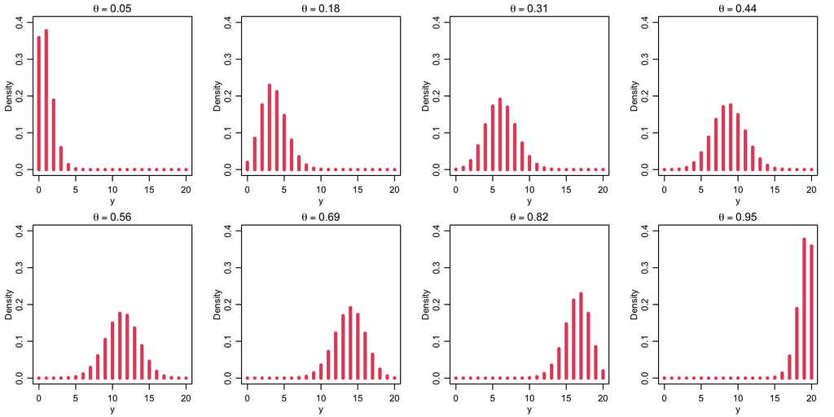

## Prior Distribution

The **prior distribution** $p(\theta)$ expresses the state of information about $\theta$ external to the dataset.

$\theta$ is treated as a **random variable**.

The formulation of $p(\theta)$ is fundamental, whether based on previous studies or on expert opinion.

It is common to use distributions that have a mathematically convenient form.

When no prior information is available, **diffuse priors** a.k.a. noninformative, vague or flat priors are recommended.

#### Example (cont.)

A Beta prior is a natural choice for a binomial likelihood due to conjugacy:
$$\theta \sim \textsf{Beta}(a,b)
\qquad\Longleftrightarrow\qquad
p(\theta) =
\frac{\Gamma(a+b)}{\Gamma(a)\Gamma(b)}
\,\theta^{a-1}(1-\theta)^{b-1},$$
where $a$ and $b$ are **hyperparameters**. The hyperparameters $a$,$b$ reflect prior “pseudo-counts” or strength of belief.

A noninformative prior is: $a=b=1$, $p(\theta)=1$ for all $0<\theta<1$ (uniform prior).

## Posterior Distribution

**Statistical inference** consists of **learning** (reducing uncertainty) about the **parameters** (characteristics) $\boldsymbol{\theta} = (\theta_1, \ldots, \theta_k)$ of a **population** (generating process) based on a **source of information** (dataset) $\boldsymbol{y} = (y_1, \ldots, y_n)$.

The **posterior distribution** $p(\theta \mid y)$ is the random mechanism that provides the updated state of information about $\theta$ after observing $y$.

**After** the observation process is carried out, $y$ is a **fixed quantity**.

**Bayes’ theorem** is the optimal rational method that guarantees logical coherence and consistency for updating the state of information about $\boldsymbol{\theta}$ according to the empirical evidence contained in $\boldsymbol{y}$:
$$p(\theta\mid y)
=
\frac{p(y\mid\theta)p(\theta)}
{\int_\Theta p(y\mid\theta)p(\theta)\,d\theta}
\propto p(y\mid\theta)p(\theta).$$
The inductive learning process through Bayes’ theorem is known as **Bayesian inference**.

Bayes’ theorem does not determine our state of information; instead, it prescribes how that state should be updated when new evidence is incorporated.

R. A. Fisher referred to $p(y\mid\theta)$ as the **likelihood**, denoted
$$\ell(\theta) = c\,p(y\mid\theta),$$
with $c$ a positive constant.

The **marginal distribution** of $y$ is
$$p(y)=\int_\Theta p(y\mid\theta)p(\theta)\,d\theta,$$
a weighted average (or mixture) of sampling distributions over the prior.

Bayes’ theorem can also be written as
$$p(\theta\mid y) \propto \ell(\theta\mid y)\,p(\theta)
\qquad\Longleftrightarrow\qquad
\log p(\theta\mid y)=\log\ell(\theta\mid y)+\log p(\theta)+c.$$

#### Example

Consider the model:
$$\begin{aligned}
y\mid\theta &\sim \textsf{Binomial}(n,\theta)\\
\theta &\sim \textsf{Beta}(a,b)
\end{aligned}$$

Under this model, the **posterior distribution** of $\theta$ is
$$\theta\mid y \sim \textsf{Beta}(a+y,\,b+n-y)
\qquad\Longleftrightarrow\qquad
p(\theta\mid y)
=
\frac{\Gamma(a+b+n)}{\Gamma(a+y)\Gamma(b+n-y)}
\theta^{a+y-1}(1-\theta)^{b+n-y-1},$$
since
$$\begin{aligned}
p(\theta\mid y)
&\propto p(y\mid\theta)\,p(\theta) \\
&=
\binom{n}{y}\theta^y(1-\theta)^{n-y}
\cdot
\frac{\Gamma(a+b)}{\Gamma(a)\Gamma(b)}
\theta^{a-1}(1-\theta)^{b-1}\\
&\propto
\theta^{a+y-1}(1-\theta)^{b+n-y-1}.
\end{aligned}$$
which corresponds to the **kernel** (the density function without the normalizing constant) of a Beta distribution with parameters $a_n = a + y$ and $b_n = b + n - y$.

If it is observed that only one individual in the sample is infected $(y=1)$ and $n=20$ with $a=b=1$, then the posterior distribution of $\theta$ is $\theta\mid y \sim \textsf{Beta}(2,20)$.

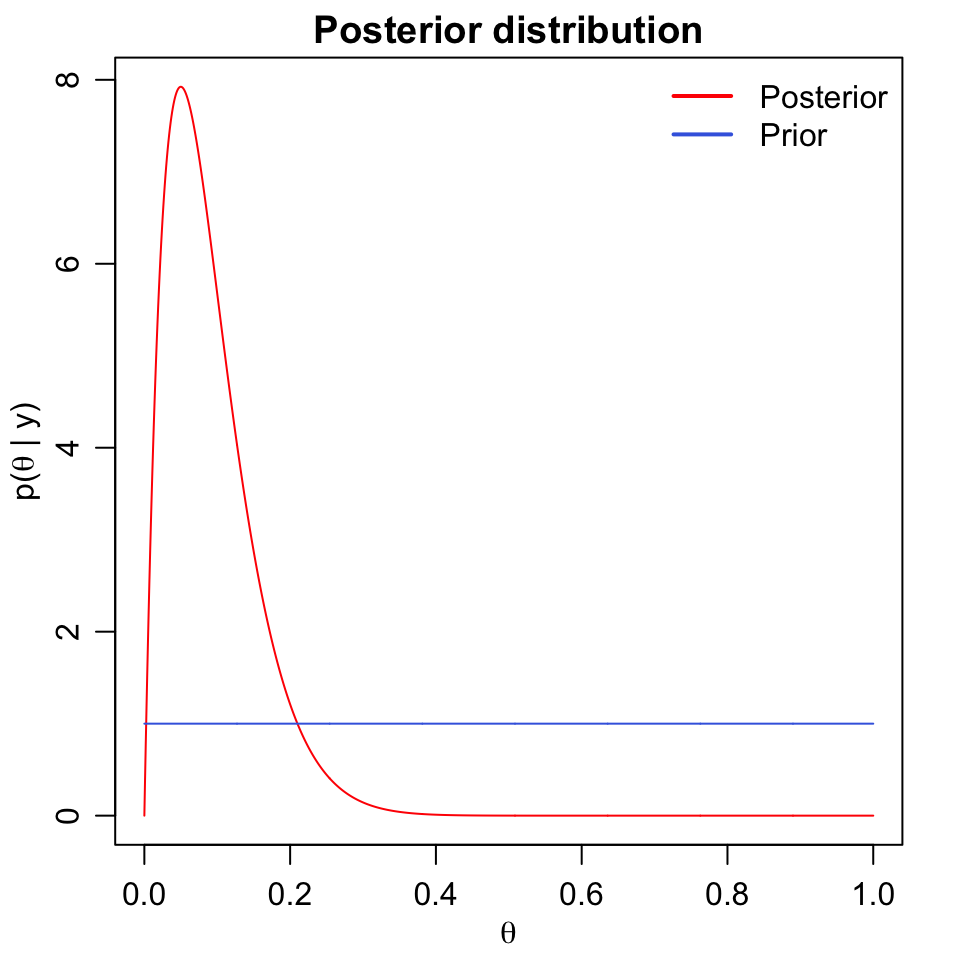

The posterior distribution $p(\theta \mid y)$ provides a framework for inferring and updating knowledge about $\theta$.

The posterior distribution is more concentrated than $p(\theta)$ because it combines the information from the data with the prior distribution, and therefore contains more information than $p(\theta)$ by itself.

It is advisable to compute the posterior distribution for a wide range of hyperparameter values in order to carry out a **sensitivity analysis**, allowing one to assess the influence of different prior specifications on the inferential results.

#### Example

The classical estimate of $\theta$ is the sample proportion of infected individuals, $\bar{y} = y/n$.

If $y = 1$, the estimate is $\bar{y} = 1/20 = 0.05$.

A common way to quantify the uncertainty of an estimate is through a **confidence interval**.

The 95% confidence interval for a population proportion $\theta$ is:
$$\bar{y} \pm 1.96 \sqrt{\frac{\bar{y}(1 - \bar{y})}{n}} = 0.05 \pm 0.0955
\rightarrow (−0.0455,0.1455).$$

This interval has asymptotically correct frequentist coverage. That is, a 95% confidence interval is supposed to contain the true parameter $\theta$ in 95% of repeated samples. However, this property does not hold in small samples (CLT).